# Primary School Data

#### M3a: GOF

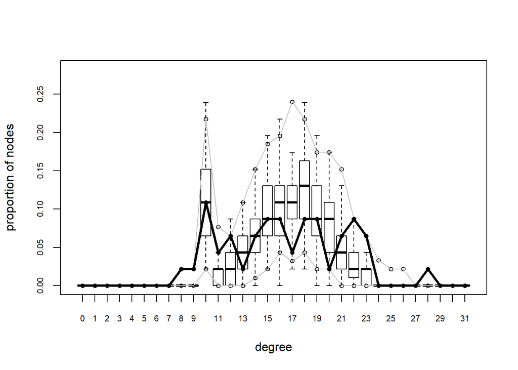

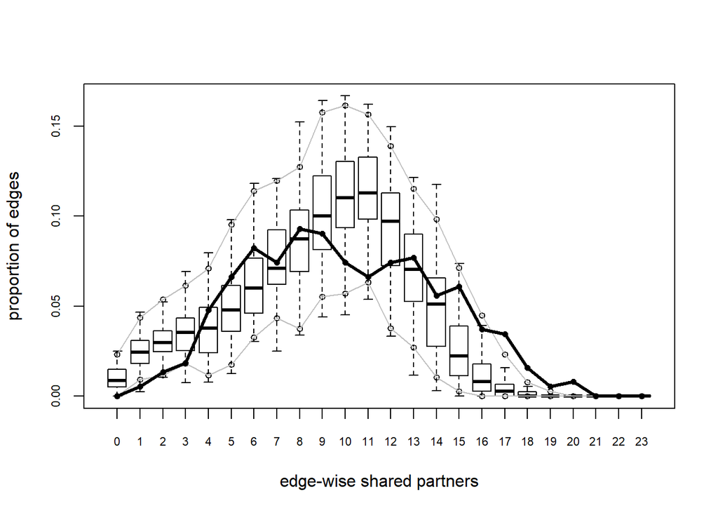

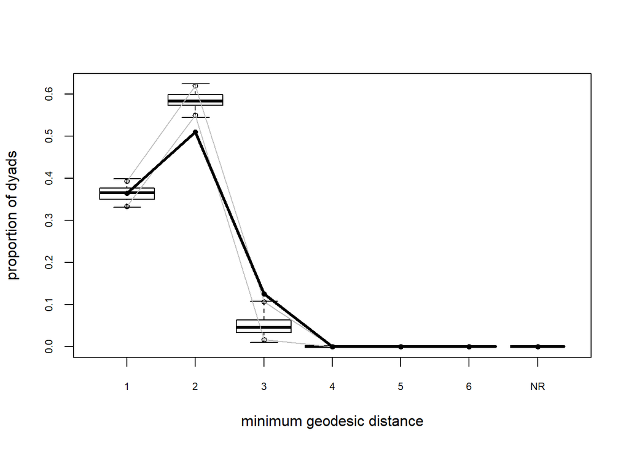

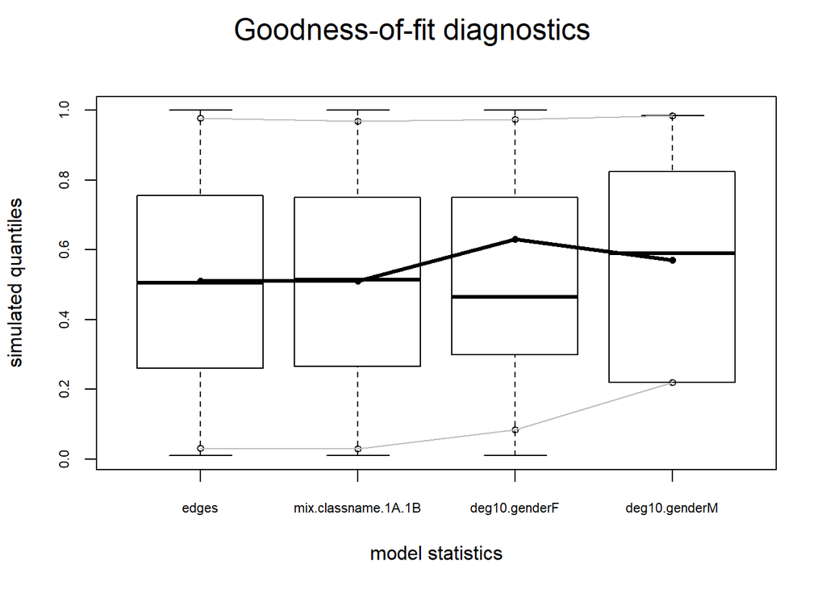

```r
plot(gof(gr1.m3a))
```

#### M3b: Diagnostics

```r
mcmc.diagnostics(gr1.m3a,center = F)
```

```
## Sample statistics summary:
##
## Iterations = 1e+05:82010000
## Thinning interval = 10000
## Number of chains = 1
## Sample size per chain = 8192
##
## 1. Empirical mean and standard deviation for each variable,
##    plus standard error of the mean:
##
##                         Mean      SD Naive SE Time-series SE
## edges               376.1842 16.8687  0.18637        0.21221
## mix.classname.1A.1B  41.4418  6.7974  0.07510        0.07510
## deg10.genderF         4.6050  2.2196  0.02452        0.02987
## deg10.genderM         0.8912  0.9993  0.01104        0.01132
##
## 2. Quantiles for each variable:
##
##                     2.5% 25% 50% 75% 97.5%
## edges                344 364 376 388   409
## mix.classname.1A.1B   29  37  41  46    55
## deg10.genderF          1   3   5   6     9
## deg10.genderM          0   0   1   1     3
##
##
## Sample statistics cross-correlations:
##                          edges mix.classname.1A.1B deg10.genderF
## edges                1.0000000           0.6177909    -0.7073958
## mix.classname.1A.1B  0.6177909           1.0000000    -0.4075913
## deg10.genderF       -0.7073958          -0.4075913     1.0000000
## deg10.genderM       -0.4334966          -0.2596397     0.2743219
##                     deg10.genderM
## edges                  -0.4334966
## mix.classname.1A.1B    -0.2596397
## deg10.genderF           0.2743219
## deg10.genderM           1.0000000
##
## Sample statistics auto-correlation:
## Chain 1
##                 edges mix.classname.1A.1B deg10.genderF deg10.genderM
```

[output cut: 9 more lines]

```
##
## Fraction in 1st window = 0.1
## Fraction in 2nd window = 0.5
##
##               edges mix.classname.1A.1B       deg10.genderF
##             1.28776            -0.15413            -0.06888
##       deg10.genderM
##            -0.37971
##
## Individual P-values (lower = worse):
##               edges mix.classname.1A.1B       deg10.genderF
##           0.1978280           0.8775110           0.9450861
##       deg10.genderM
##           0.7041627
## Joint P-value (lower = worse):  0.2192427 .
```

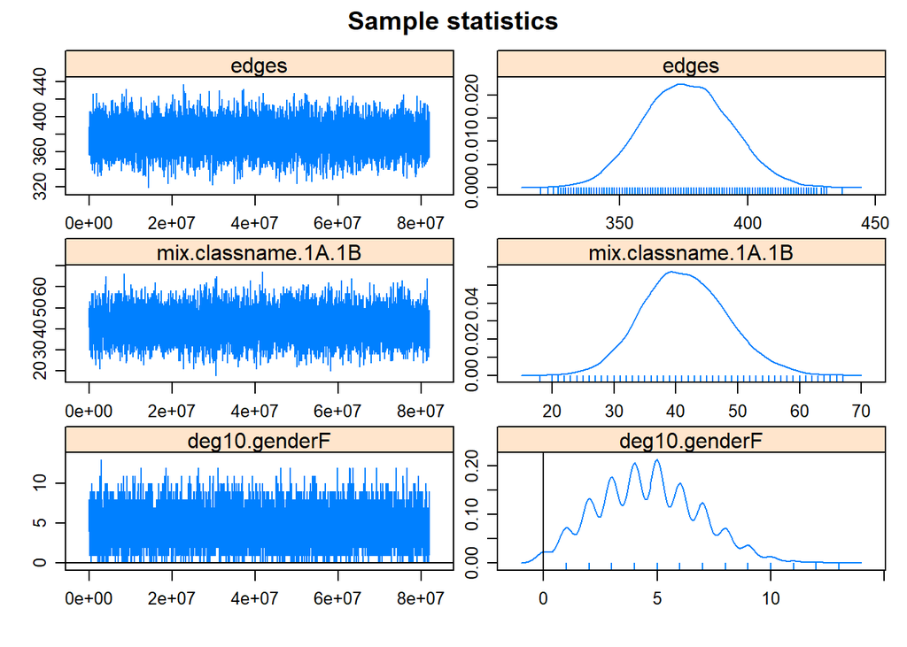

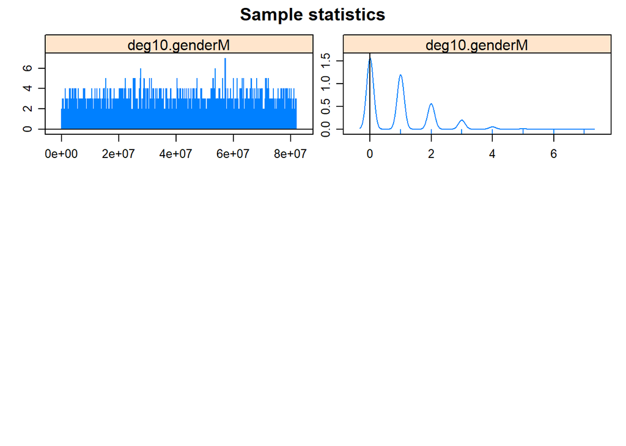

```
##
## MCMC diagnostics shown here are from the last round of simulation, prior to computation of final parameter estimates. Because the final estimates are refinements of those used for this simulation run, these diagnostics may understate model performance. To directly assess the performance of the fi…
```

##### The best model for `classname` is Model 2 with edges, nodemix and degree 10.

### Model 6: edges and nodemix `gender`

```r
#M6
#gr1.m6 <- ergm(gr1~edges + nodemix('gender', base=c(3)))
summary(gr1.m6)
```

```
##
## ==========================
## Summary of model fit
## ==========================
##
## Formula:   gr1 ~ edges + nodemix("gender", base = c(3))
##
## Iterations:  4 out of 20
##
## Monte Carlo MLE Results:
##                Estimate Std. Error MCMC % p-value
## edges           -0.2877     0.1330      0  0.0307 *
## mix.gender.F.F  -0.2620     0.1825      0  0.1514
## mix.gender.F.M  -0.3970     0.1618      0  0.0143 *
## ---
## Signif. codes:  0 '***' 0.001 '**' 0.01 '*' 0.05 '.' 0.1 ' ' 1
##
##      Null Deviance: 1435  on 1035  degrees of freedom
##  Residual Deviance: 1352  on 1032  degrees of freedom
##
## AIC: 1358    BIC: 1372    (Smaller is better.)
```

#### M6: GOF

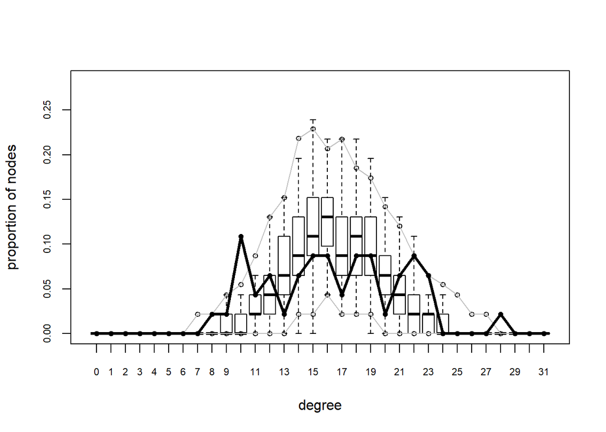

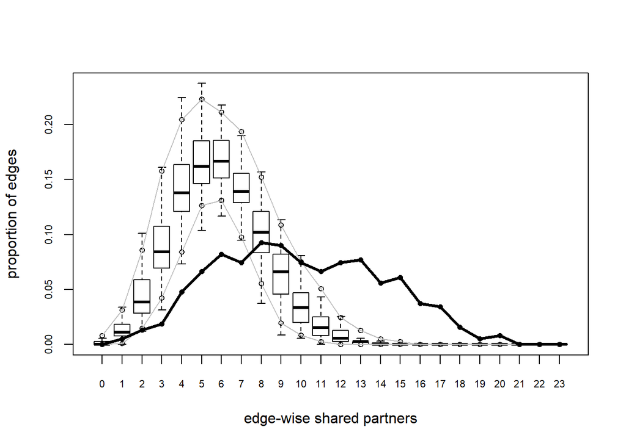

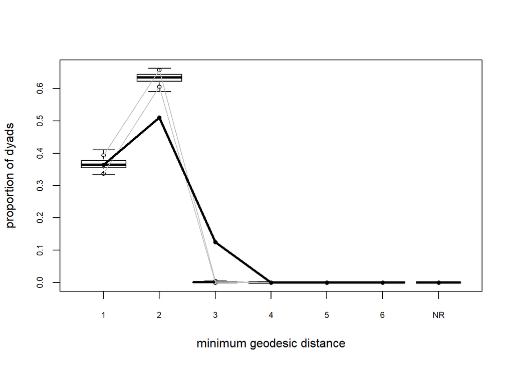

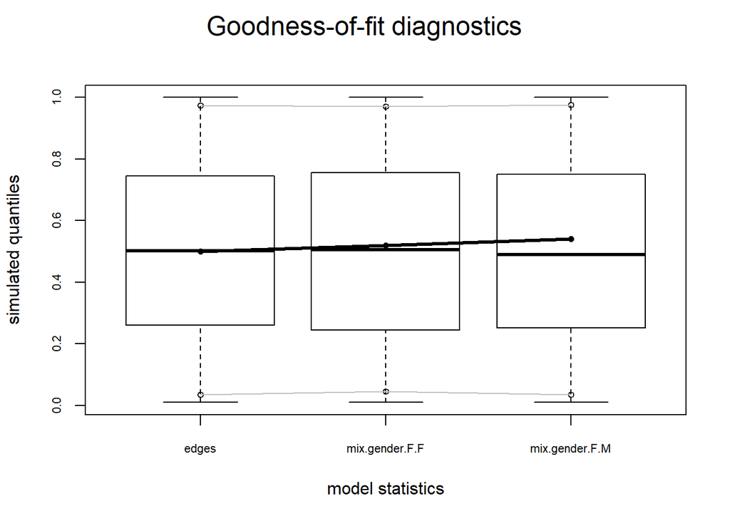

```r
plot(gof(gr1.m6))
```

###Model 7: M6 + degree(10)

```r
#M7
#gr1.m7 <- ergm(gr1~edges + nodemix('gender', base=c(1,3))+ degree(10,'gender'))
summary(gr1.m7)
```

```
##
## ==========================
## Summary of model fit
## ==========================
##
## Formula:   gr1 ~ edges + nodemix("gender", base = c(1, 3)) + degree(10,
##     "gender")
##
## Iterations:  5 out of 20
##
## Monte Carlo MLE Results:
##                Estimate Std. Error MCMC % p-value
## edges          -0.28769    0.09937      0 0.00387 **
## mix.gender.F.M -0.26995    0.13162      0 0.04051 *
## deg10.genderF   2.95047    0.65726      0 < 1e-04 ***
## deg10.genderM   1.43842    1.00490      0 0.15262
## ---
## Signif. codes:  0 '***' 0.001 '**' 0.01 '*' 0.05 '.' 0.1 ' ' 1
##
##      Null Deviance: 1435  on 1035  degrees of freedom
##  Residual Deviance: 1339  on 1031  degrees of freedom
##
## AIC: 1347    BIC: 1367    (Smaller is better.)
```

#### M7: GOF

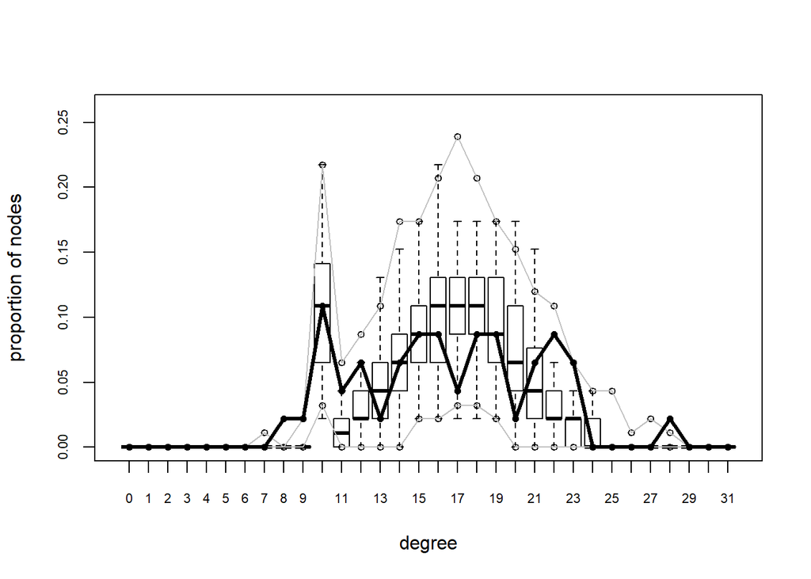

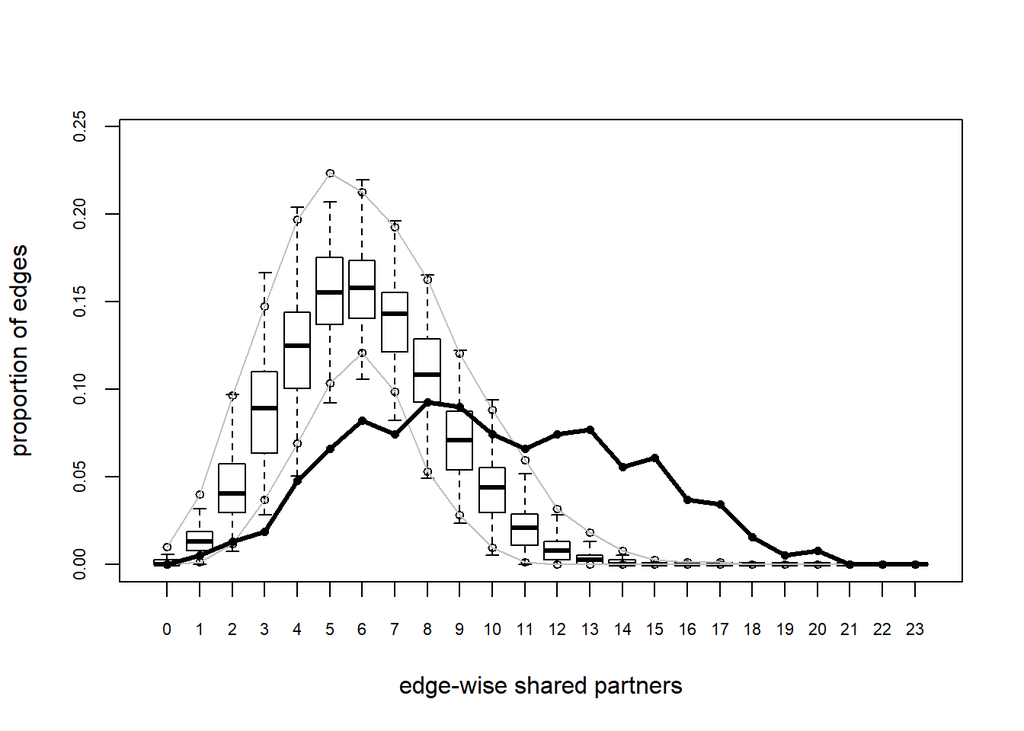

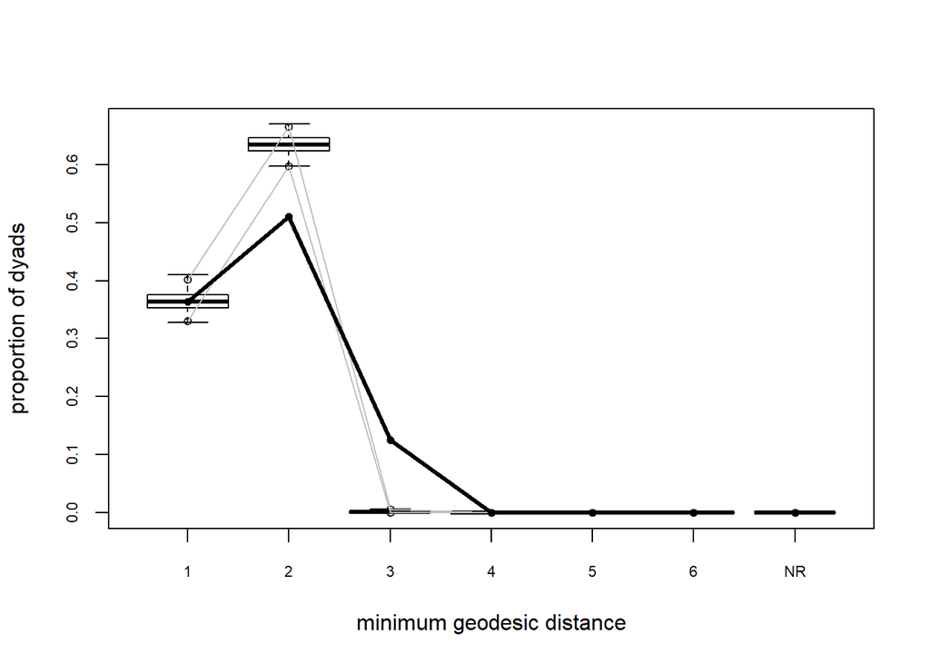

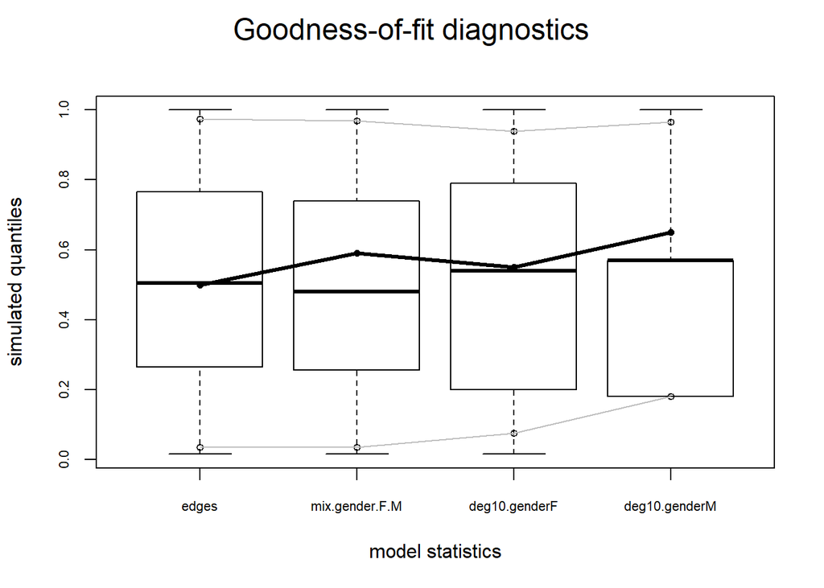

```r
plot(gof(gr1.m7))
```

Model is not a good fit for edgewise-shared parter.

#### M7: Diagnostics

```r
mcmc.diagnostics(gr1.m7)
```

```
## Sample statistics summary:
##
## Iterations = 16384:4209664
## Thinning interval = 1024
## Number of chains = 1
## Sample size per chain = 4096
##
## 1. Empirical mean and standard deviation for each variable,
##    plus standard error of the mean:
##
##                  Mean     SD Naive SE Time-series SE
## edges          2.5037 22.767  0.35574        0.86505
## mix.gender.F.M 2.6982 13.299  0.20780        0.46159
## deg10.genderF  0.1953  2.333  0.03646        0.09559
## deg10.genderM  0.1719  1.161  0.01815        0.02891
##
## 2. Quantiles for each variable:
##
##                2.5% 25% 50% 75% 97.5%
## edges           -43 -13   3  18    46
## mix.gender.F.M  -23  -6   3  12    28
## deg10.genderF    -4  -2   0   2     5
## deg10.genderM    -1  -1   0   1     3
##
##
## Sample statistics cross-correlations:
##                     edges mix.gender.F.M deg10.genderF deg10.genderM
## edges           1.0000000      0.8198893    -0.7462529    -0.4873988
## mix.gender.F.M  0.8198893      1.0000000    -0.5888493    -0.4092457
## deg10.genderF  -0.7462529     -0.5888493     1.0000000     0.2524597
## deg10.genderM  -0.4873988     -0.4092457     0.2524597     1.0000000
##
## Sample statistics auto-correlation:
## Chain 1
##              edges mix.gender.F.M deg10.genderF deg10.genderM
## Lag 0    1.0000000      1.0000000     1.0000000    1.00000000
## Lag 1024 0.6637730      0.5272051     0.6855613    0.26920126
## Lag 2048 0.4885136      0.3406639     0.5354588    0.13252597
## Lag 3072 0.3691427      0.2320278     0.4179459    0.08912821
## Lag 4096 0.2952642      0.1887677     0.3307975    0.05613864
## Lag 5120 0.2379797      0.1648891     0.2462943    0.04149847
##
## Sample statistics burn-in diagnostic (Geweke):
## Chain 1
##
## Fraction in 1st window = 0.1
## Fraction in 2nd window = 0.5
##
##          edges mix.gender.F.M  deg10.genderF  deg10.genderM
##        -1.4449        -0.3924         1.2274         1.9427
##
## Individual P-values (lower = worse):
##          edges mix.gender.F.M  deg10.genderF  deg10.genderM
##     0.14848213     0.69473337     0.21967368     0.05205565
## Joint P-value (lower = worse):  0.05691672 .
```

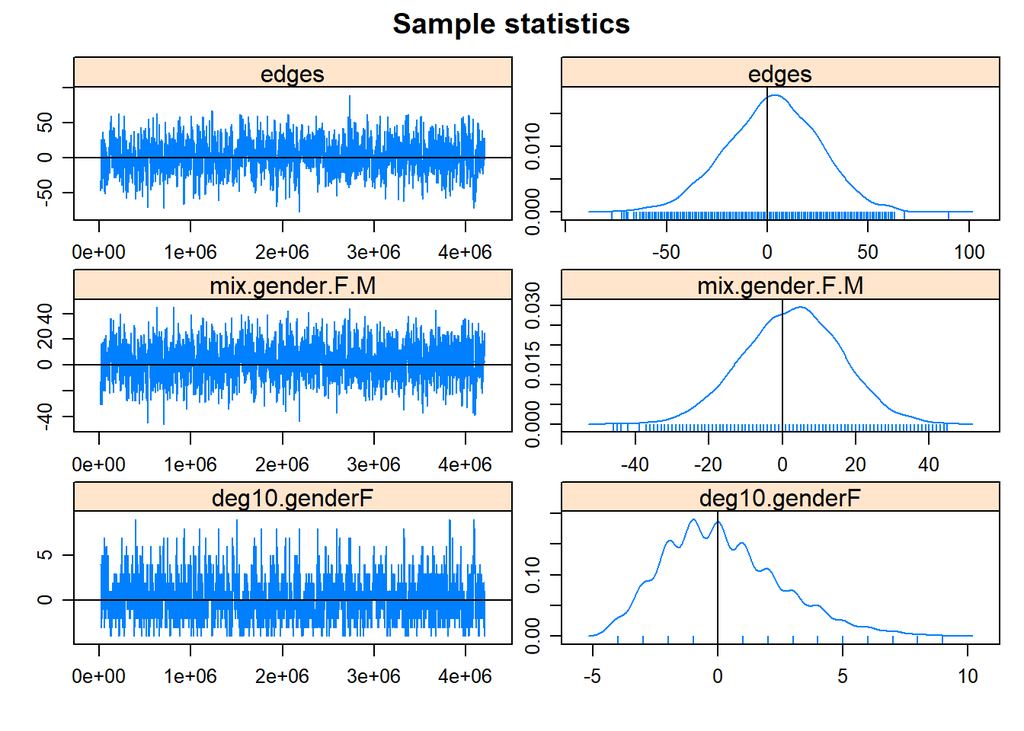

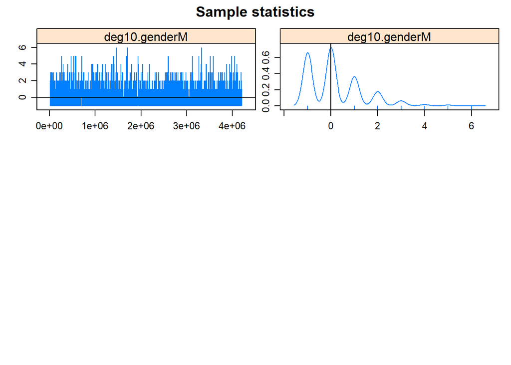

```
##
## MCMC diagnostics shown here are from the last round of simulation, prior to computation of final parameter estimates. Because the final estimates are refinements of those used for this simulation run, these diagnostics may understate model performance. To directly assess the performance of the fi…
```

Let us try to Fit GOF model using gwesp

### Other Models tried to fit for gender mix

```r
#gr1.m8 <- ergm(gr1~edges + nodemix('gender',base=c(1,3)) + degree(10,'gender') + gwesp(cutoff=20)) #failed
#gr1.m9 <- ergm(gr1~edges + nodemix('gender',base=c(1,3)) + degree(10,'gender') + gwesp(3:7)) #failed
#gr1.m10 <- ergm(gr1~edges + nodemix('gender',base=c(1,3)) + degree(10,'gender') + gwesp(12)) #failed
#gr1.m11 <- ergm(gr1~edges + nodemix('gender', base = c(1,3))+ degree(10) + concurrent('gender')) #failed
#gr1.m12 <- ergm(gr1~edges + sociality('gender',base=1)) #too many coefficients
```

### Model 14: Combine M2 and M7 ie mix classname, mix gender and homophily for gender at degree 10.

```r
#M14
#gr1.m14 <- ergm(gr1~edges + nodemix('gender',base = c(1,3)) + nodemix('classname',base = c(1,3)) +
#                  degree(10,'gender'))
summary(gr1.m14)
```

```
##
## ==========================
## Summary of model fit
## ==========================
##
## Formula:   gr1 ~ edges + nodemix("gender", base = c(1, 3)) + nodemix("classname",
##     base = c(1, 3)) + degree(10, "gender")
##
## Iterations:  5 out of 20
##
## Monte Carlo MLE Results:
##                     Estimate Std. Error MCMC % p-value
## edges                 1.1037     0.1399      0 < 1e-04 ***
## mix.gender.F.M       -0.5075     0.1647      0 0.00212 **
## mix.classname.1A.1B  -3.1685     0.1891      0 < 1e-04 ***
## deg10.genderF         3.5072     0.6881      0 < 1e-04 ***
## deg10.genderM         1.6584     1.0734      0 0.12264
## ---
## Signif. codes:  0 '***' 0.001 '**' 0.01 '*' 0.05 '.' 0.1 ' ' 1
##
##      Null Deviance: 1434.8  on 1035  degrees of freedom
##  Residual Deviance:  920.8  on 1030  degrees of freedom
##
## AIC: 930.8    BIC: 955.5    (Smaller is better.)
```

#### M14: GOF

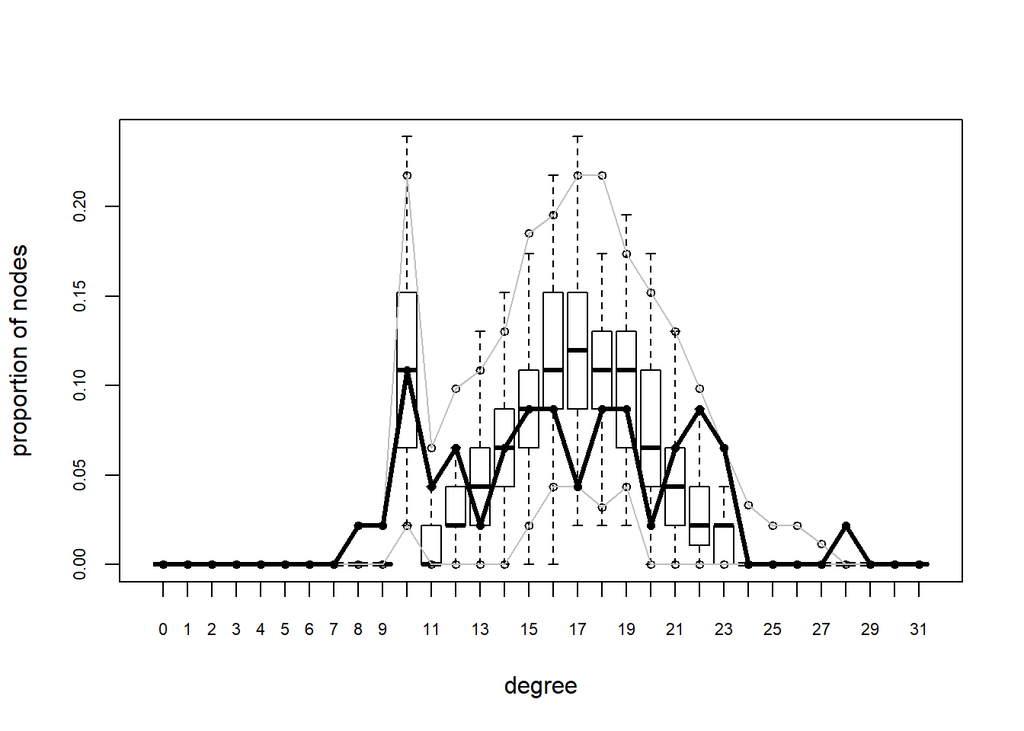

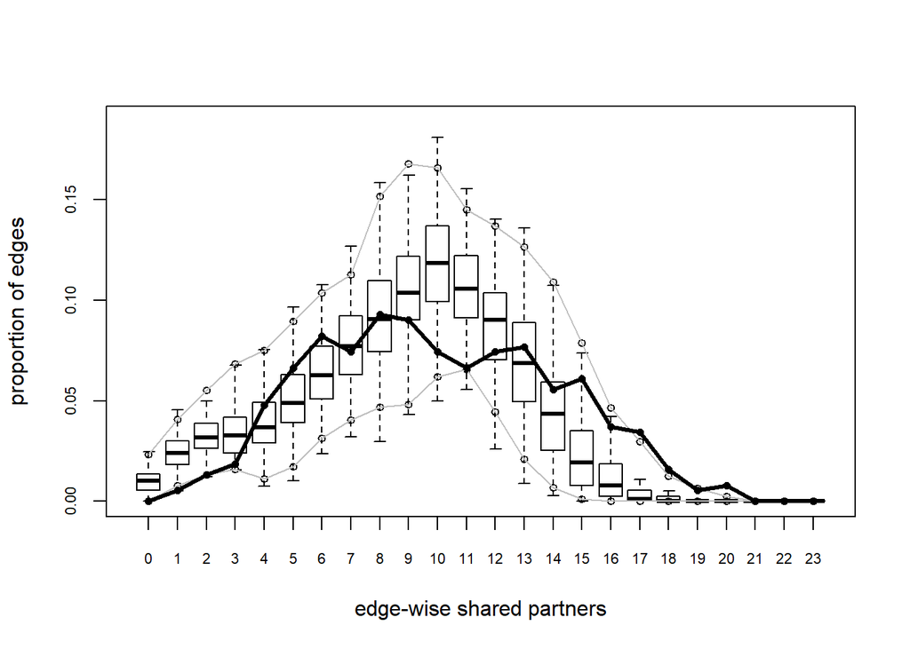

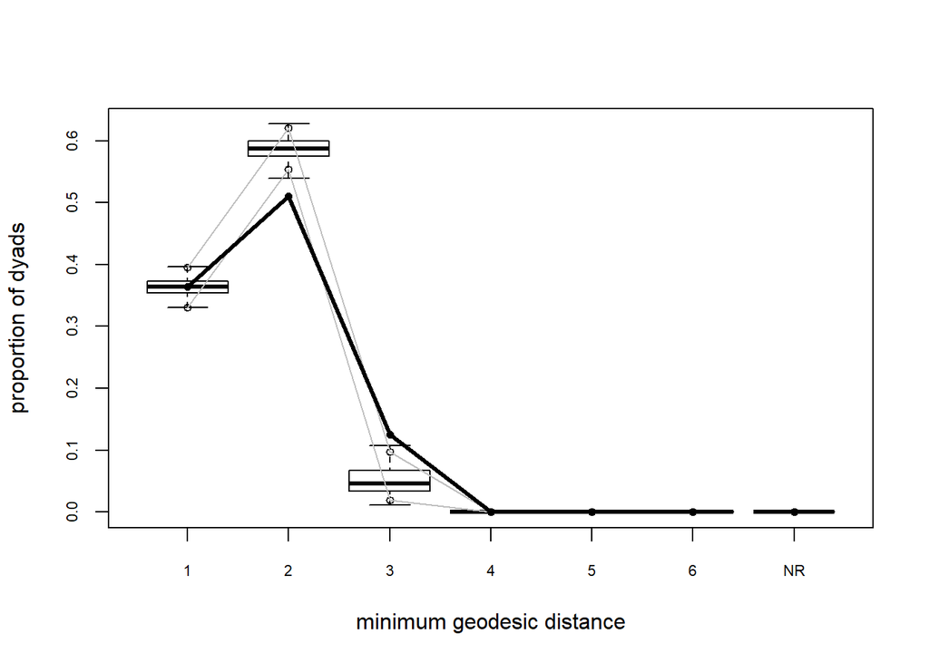

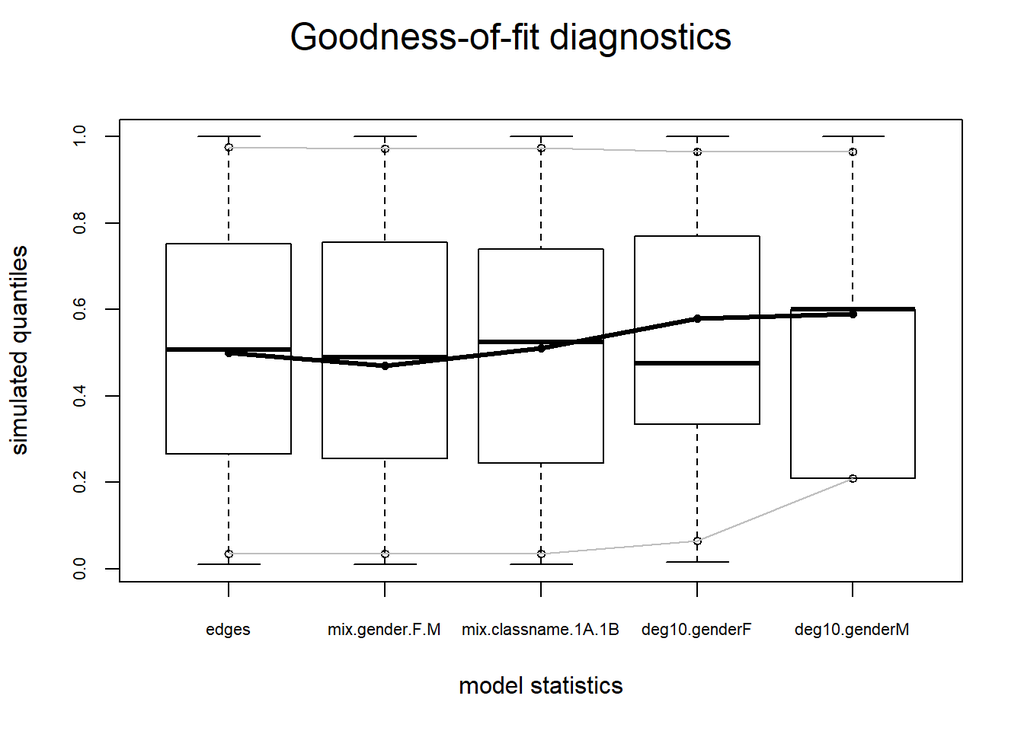

```r
plot(gof(gr1.m14))
```

GOF for this model shows good results. Let us check diagnostics.

#### M14: Diagnostics

```r
mcmc.diagnostics(gr1.m14,center = F)
```

```
## Sample statistics summary:
##
## Iterations = 16384:4209664
## Thinning interval = 1024
## Number of chains = 1
## Sample size per chain = 4096
##
## 1. Empirical mean and standard deviation for each variable,
##    plus standard error of the mean:
##
##                         Mean     SD Naive SE Time-series SE
## edges               380.0991 16.619  0.25967        0.75317
## mix.gender.F.M      178.5947 10.438  0.16310        0.43528
## mix.classname.1A.1B  42.4502  6.897  0.10776        0.18648
## deg10.genderF         3.6953  2.040  0.03187        0.10353
## deg10.genderM         0.9531  1.029  0.01608        0.02794
##
## 2. Quantiles for each variable:
##
##                      2.5% 25% 50%   75% 97.5%
## edges               346.4 369 380 391.2   412
## mix.gender.F.M      157.0 172 179 186.0   198
## mix.classname.1A.1B  29.0  38  42  47.0    57
## deg10.genderF         0.0   2   4   5.0     8
## deg10.genderM         0.0   0   1   1.0     3
##
##
## Sample statistics cross-correlations:
##                          edges mix.gender.F.M mix.classname.1A.1B
## edges                1.0000000      0.8072173           0.6291671
## mix.gender.F.M       0.8072173      1.0000000           0.4406217
## mix.classname.1A.1B  0.6291671      0.4406217           1.0000000
## deg10.genderF       -0.6972589     -0.5369200          -0.4088585
## deg10.genderM       -0.4173449     -0.3661664          -0.2411303
##                     deg10.genderF deg10.genderM
## edges                  -0.6972589    -0.4173449
## mix.gender.F.M         -0.5369200    -0.3661664
## mix.classname.1A.1B    -0.4088585    -0.2411303
## deg10.genderF           1.0000000     0.2530371
## deg10.genderM           0.2530371     1.0000000
```

[output cut: 20 more lines]

```
##
## Fraction in 1st window = 0.1
## Fraction in 2nd window = 0.5
##
##               edges      mix.gender.F.M mix.classname.1A.1B
##             -0.1616             -0.1166              0.9767
##       deg10.genderF       deg10.genderM
##              0.2943              0.3153
##
## Individual P-values (lower = worse):
##               edges      mix.gender.F.M mix.classname.1A.1B
##           0.8716344           0.9071952           0.3287004
##       deg10.genderF       deg10.genderM
##           0.7685134           0.7524977
## Joint P-value (lower = worse):  0.7149869 .
```

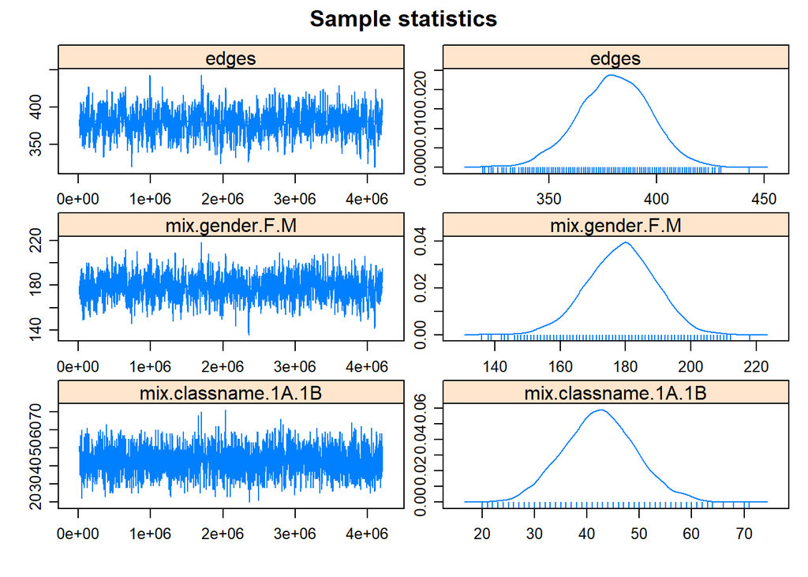

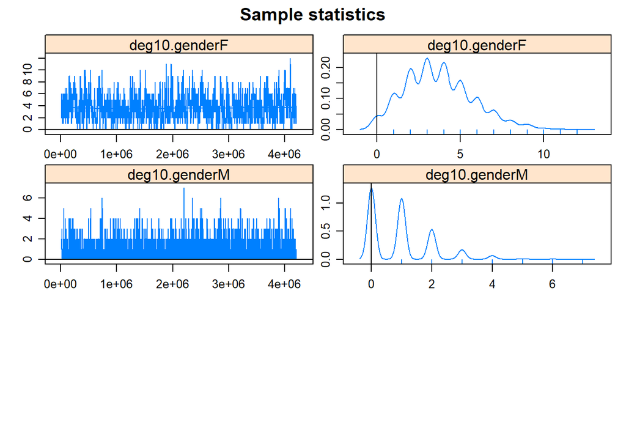

```
##
## MCMC diagnostics shown here are from the last round of simulation, prior to computation of final parameter estimates. Because the final estimates are refinements of those used for this simulation run, these diagnostics may understate model performance. To directly assess the performance of the fi…
```

Cross-correlation, auto-correlation and Geweke stats are good. Overall this model is good, but let us try one more model with nodematch on gender.

### Model 16: Edges, nodemix `classname`, nodematch `gender` and degree 10

```r
#M16
#gr1.m16 <- ergm(gr1~edges + nodemix('classname',base=c(1,3))+ nodematch('gender',diff=T) + degree(10))
summary(gr1.m16)
```

[output not shown]

#### M16: GOF

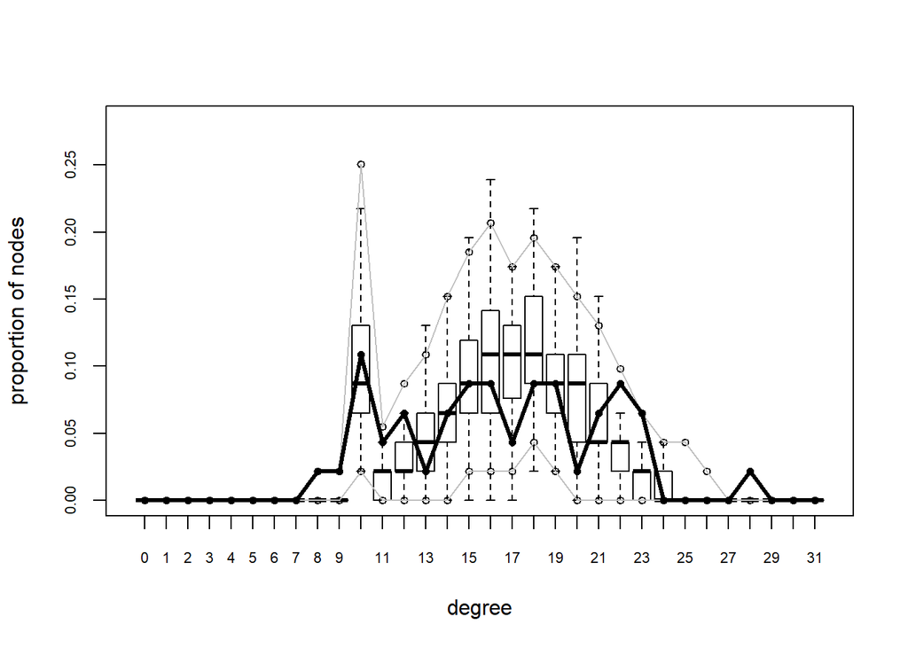

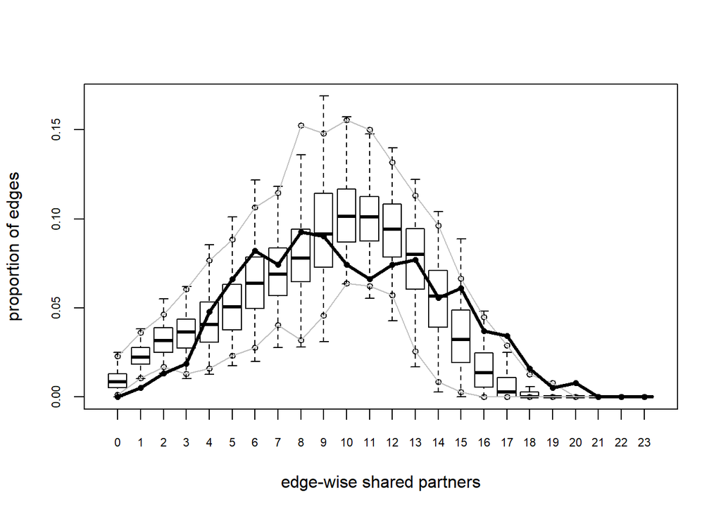

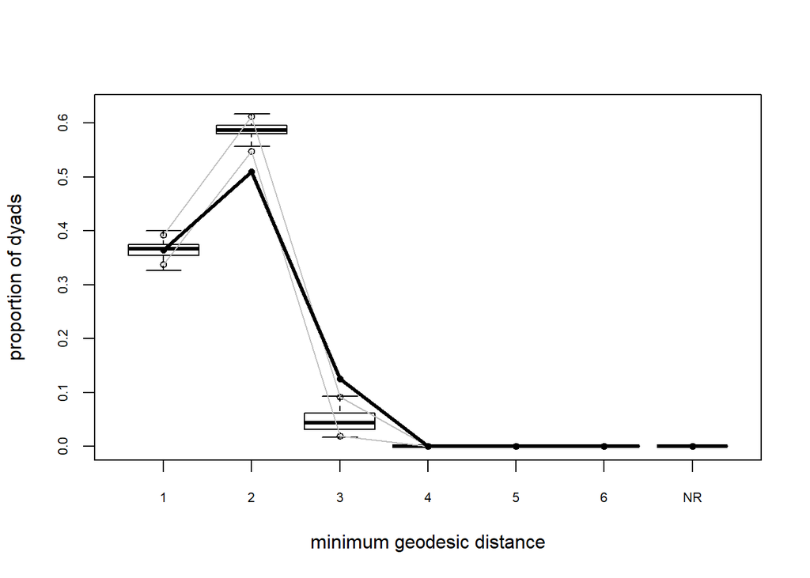

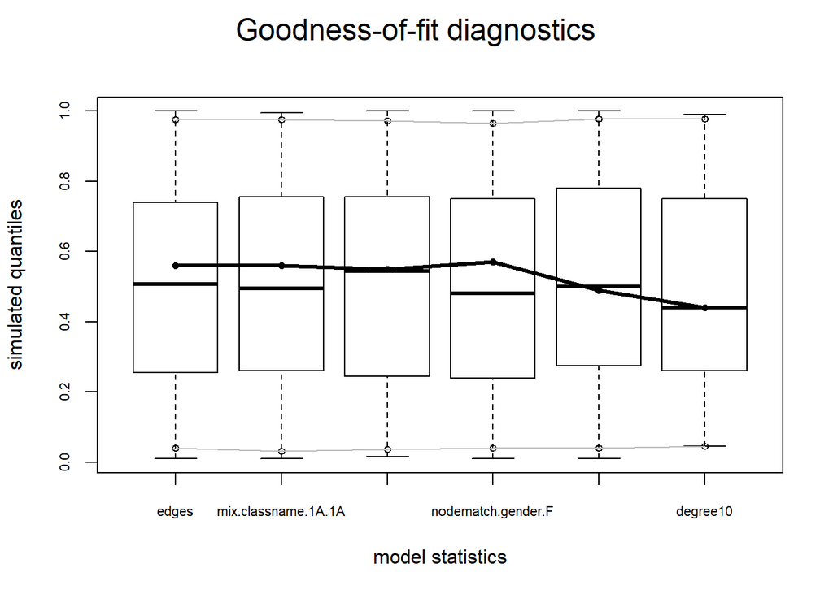

```r
plot(gof(gr1.m16))
```

Goodness of Fit shows good results for this model.